# Assignment 3

Joseph Walker

October 21, 2016

Assignment 3 – Joseph Walker – jpwalker625@gmail.com

### Problem 1

Use the data file student_data.csv to generate the following. Note: to receive credit, use only base graphics to complete the problems. - Read data file student_data.csv into a data frame named sdf, and attach the data frame.

```r
sdf <- read.csv("student_data.csv")
```

Use sdf to complete the following plots: A. Use base graphics plot to graph math by write. Use a filled triangle point (pch = 24) and fill color (bg) blue to build your graph. Add a custom main title to your graph.

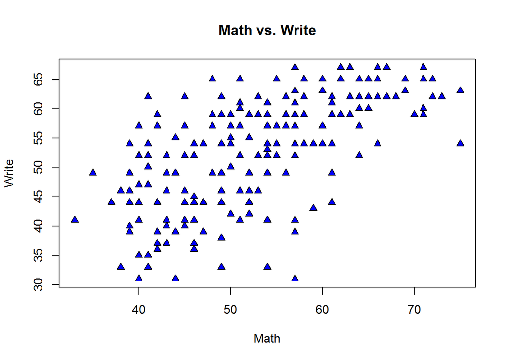

```r
plot(sdf$math, sdf$write, type = "p", main = "Math vs. Write", xlab = 'Math', ylab = 'Write', pch = 24, bg = "blue")
```

B. Use the base graphics boxplot function to generate an orange box plot for the sdf read scores. Add the label “Reading Scores” to the x axis.

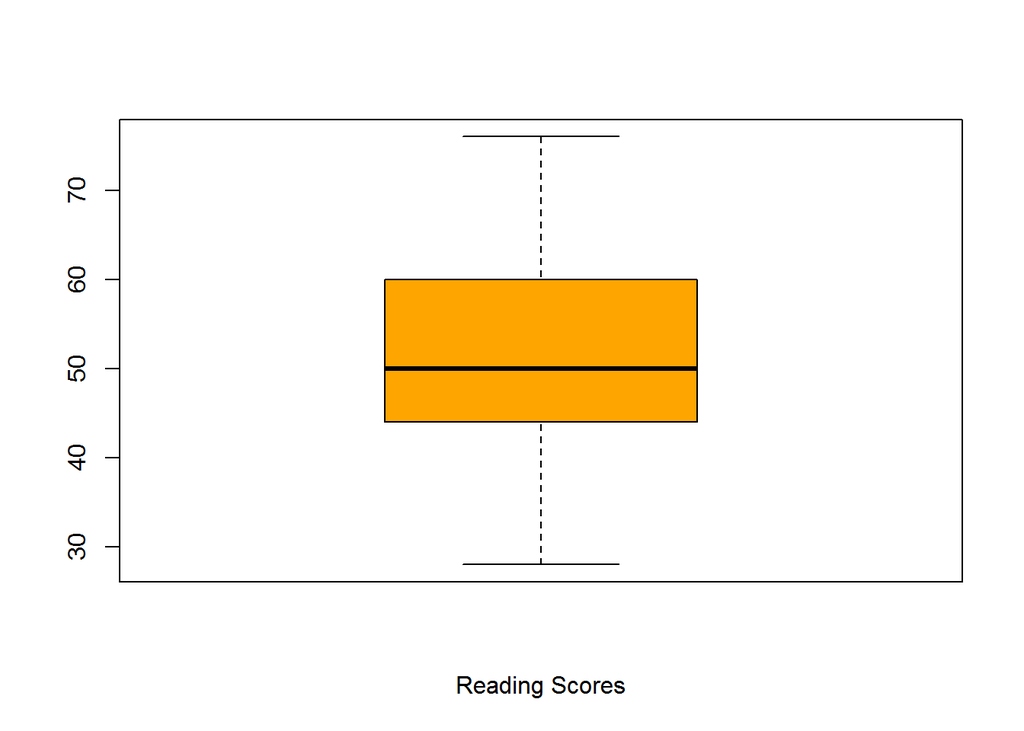

```r
boxplot(sdf$read, xlab = "Reading Scores", col = "orange")
```

### Problem 2

Download (from Canvas) the resource file state_dataset.csv to complete the following problems: Create a data frame state_df consisting of the columns in state_dataset.csv and an additonal column of corresponding state abbreviations using the built-in data vector state.abb.

```r
state_df <- read.csv("state_dataset.csv")
state_df <- cbind(state_df, state.abb)
str(state_df)
```

```
## 'data.frame':    50 obs. of  10 variables:
##  $ name       : Factor w/ 50 levels "Alabama","Alaska",..: 1 2 3 4 5 6 7 8 9 10 ...
##  $ population : int  3615 365 2212 2110 21198 2541 3100 579 8277 4931 ...
##  $ income     : int  3624 6315 4530 3378 5114 4884 5348 4809 4815 4091 ...
##  $ illiteracy : num  2.1 1.5 1.8 1.9 1.1 0.7 1.1 0.9 1.3 2 ...
##  $ life_expect: num  69 69.3 70.5 70.7 71.7 ...
##  $ murder     : num  15.1 11.3 7.8 10.1 10.3 6.8 3.1 6.2 10.7 13.9 ...
##  $ hs_grade   : num  41.3 66.7 58.1 39.9 62.6 63.9 56 54.6 52.6 40.6 ...
##  $ frost      : int  20 152 15 65 20 166 139 103 11 60 ...
##  $ area       : int  50708 566432 113417 51945 156361 103766 4862 1982 54090 58073 ...
##  $ state.abb  : Factor w/ 50 levels "AK","AL","AR",..: 2 1 4 3 5 6 7 8 9 10 ...
```

Use state_df to plot using base graphics only: A. A scatterplot of illiteracy by murder with a title, using the X character.

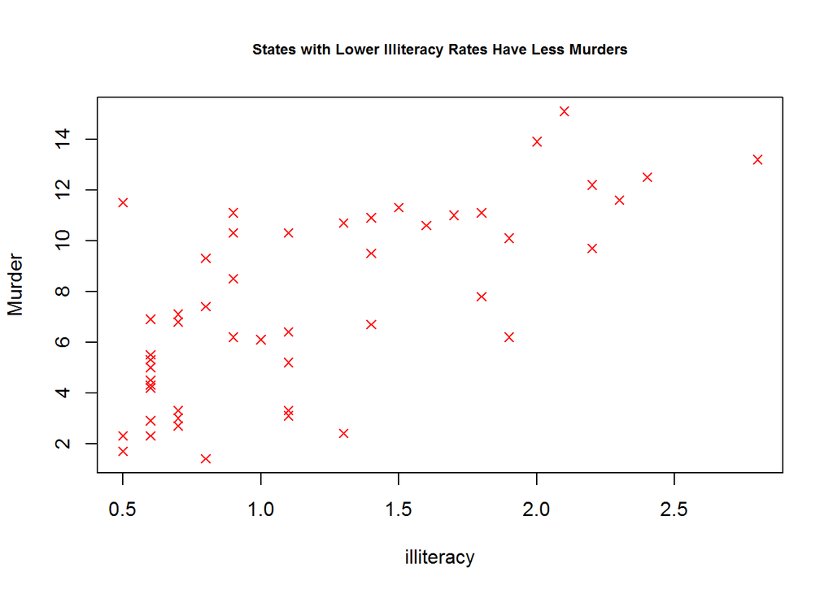

```r
plot(state_df$illiteracy, state_df$murder,  xlab = "illiteracy", ylab = "Murder", main =  "States with Lower Illiteracy Rates Have Less Murders", cex.main = .75, pch = 4, col = 'red')
```

B. An orange barplot consiting of the state abbreviations on the x axis and the frost value on the y axis

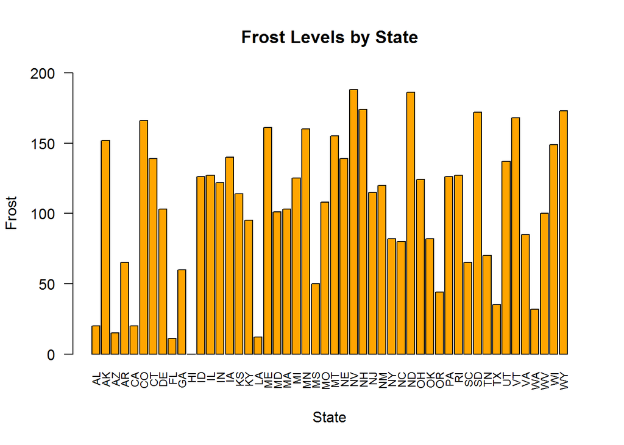

```r
barplot(height = state_df$frost,names.arg = state.abb, cex.names = .75, ylim = c(0,200),xlab = 'State',ylab = "Frost", col = "orange", las = 2,main = "Frost Levels by State" )
```

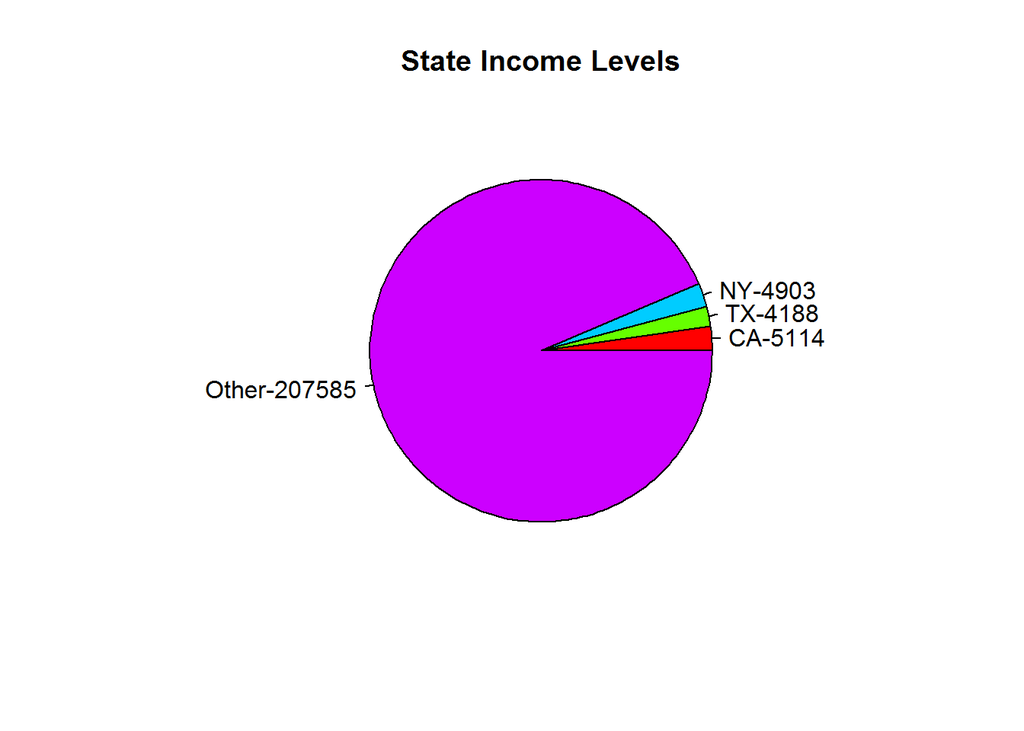

```r
slices <- c(state_df$income[state_df$state.abb == 'CA'],state_df$income[state_df$state.abb == 'TX'],state_df$income[state_df$state.abb == 'NY'], sum(state_df$income[!(state_df$state.abb %in% c('CA','NY','TX'))]))
labels <- c('CA', 'TX', 'NY','Other')
labels <- paste(labels,slices, sep = "-")
pie(x = slices, labels = labels, main = "State Income Levels", col = rainbow(length(labels),start = 1, end = .8))
```

#### Problem 3A Build the data frame:

Use the data set in yrbssn.csv.zip (unzip) on our Canvas site to complete this problem.

Create a data frame yrbssn_df for the years 2011 and 2013 only, with the following field names listed in column 1, source in column 2 of the table below. Use the field names in column 1, and the mappings in column 3.

```r
#The following code used to build the table, **not part of the solution**
yrbssn_df.Field.Name <- c('year', 'gender', 'grade', 'height', 'weight', 'active', 'lifting')

source.yrbssncsv.Data.File.Field <- c('year', 'sex', 'grade', 'stheight', 'stweight', 'qn80','qnmusclestrength')

field.value.mappings <-c('numeric,as given','1, 2 map to female, male','1, 2, 3, 4 map to grades 9, 10, 11, 12','meters (convert to inches)','kg (convert to pounds)','During the past 7 days, on how many days were you physically active for a total of at least 60 minutes per day? (Add up all the time you spent in any kind of physical activity that increased your heart rate and made you breathe hard some of the time.) A. 0 days B. 1 day C. 2 days D. 3 days E. 4 days F. 5 days G. 6 days H. 7 days','On how many of the past 7 days did you do exercises to strengthen or tone your muscles, such as push-ups, sit-ups, or weight lifting? A. 0 days B. 1 day C. 2 days D. 3 days E. 4 days F. 5 days G. 6 days H. 7 days')

options(width = 10000)

setup <- data.frame(yrbssn_df.Field.Name, source.yrbssncsv.Data.File.Field, field.value.mappings,row.names = NULL,check.rows = TRUE)
colnames(setup) <- c("field name", 'source field', 'field value mappings')
library(knitr)
kable(setup)
```

| field name | source field | field value mappings |
| --- | --- | --- |
| year | year | numeric,as given |
| gender | sex | 1, 2 map to female, male |
| grade | grade | 1, 2, 3, 4 map to grades 9, 10, 11, 12 |
| height | stheight | meters (convert to inches) |
| weight | stweight | kg (convert to pounds) |
| active | qn80 | During the past 7 days, on how many days were you physically active for a total of at least 60 minutes per day? (Add up all the time you spent in any kind of physical activity that increased your hear… |
| lifting | qnmusclestrength | On how many of the past 7 days did you do exercises to strengthen or tone your muscles, such as push-ups, sit-ups, or weight lifting? A. 0 days B. 1 day C. 2 days D. 3 days E. 4 days F. 5 days G. 6 da… |

*————————————————————————————–*

In a single code chunk, include the code that:

- reads in the csv to yrbssn_df
- performs the field mappings, operations to transform the data set
- Use a call to str(yrbssn_df) to verify your results (do not print the entire data frame!)

```r
#Read in the data
yrbssn_df <- read.csv("yrbssn.csv")

#subset the data as specified
yrbssn_df <- yrbssn_df[yrbssn_df$year %in% c('2011','2013'),c("year","sex","grade","stheight","stweight","qn80","qnmusclestrength")]

#rename column names
#(yrbssn_df.Field.Name assigned in code above that built the field names/mappings table)
colnames(yrbssn_df) <- c(paste(yrbssn_df.Field.Name,sep = ','))

#transform field value mappings
yrbssn_df$year <- as.numeric(yrbssn_df$year)
yrbssn_df$gender[yrbssn_df$gender == '1'] <- 'female'
yrbssn_df$gender[yrbssn_df$gender == '2'] <- 'male'

yrbssn_df$grade[yrbssn_df$grade == '1'] <- '9'
yrbssn_df$grade[yrbssn_df$grade == '2'] <- '10'
yrbssn_df$grade[yrbssn_df$grade == '3'] <- '11'
yrbssn_df$grade[yrbssn_df$grade == '4'] <- '12'

#conversion factor from meters to inches = 39.3701
yrbssn_df$height <- yrbssn_df$height * 39.701

#conversion factor from kgs to lbs = 2.2
yrbssn_df$weight <- yrbssn_df$weight * 2.2

str(yrbssn_df)
```

```
## 'data.frame':    29008 obs. of  7 variables:
##  $ year   : num  2011 2011 2011 2011 2011 ...
##  $ gender : chr  NA NA NA NA ...
##  $ grade  : chr  NA NA NA NA ...
##  $ height : num  NA NA NA NA NA NA NA NA NA NA ...
##  $ weight : num  NA NA NA NA NA NA NA NA NA NA ...
##  $ active : int  2 2 1 1 1 2 2 2 1 2 ...
##  $ lifting: int  1 2 1 1 1 1 1 1 1 2 ...
```

### Problem 3B

Generate a table (use the kable() function defined in the package knitr) that includes the following:

- mean height, standard deviation height, mean weight, standard deviation weight

```r
library(knitr)
stats.df <- yrbssn_df[,c('height','weight')]
stats.df <- data.frame(mean(yrbssn_df$height, na.rm = TRUE),sd(yrbssn_df$height, na.rm = TRUE),mean(yrbssn_df$weight, na.rm = TRUE),sd(yrbssn_df$weight, na.rm = TRUE))

cnames <- c('mean.height (inches)','sd.height (inches)','mean.weight (lbs)','sd.weight (lbs)')

kable(stats.df,col.names = cnames,caption = 'Summary Stats for Height & Weight',align = 'c')
```

Summary Stats for Height & Weight

| mean.height (inches) | sd.height (inches) | mean.weight (lbs) | sd.weight (lbs) |
| --- | --- | --- | --- |
| 67.10733 | 4.139654 | 148.8887 | 37.45431 |

### Problem 3C

Use base graphics to build three separate frequency plots of the following on the X axes, Frequency on the Y axes:

#### grade

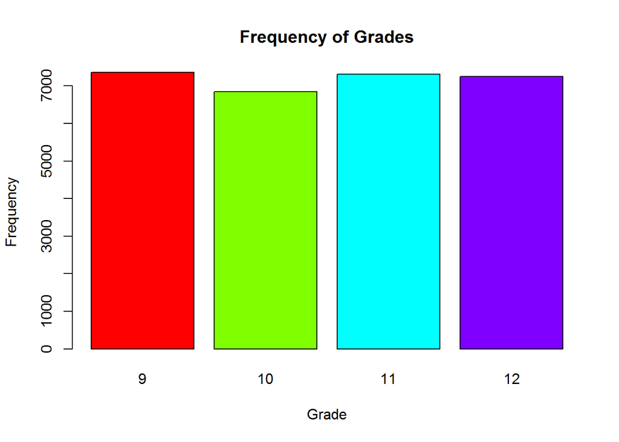

```r
library(forcats)
yrbssn_df$grade <- factor(yrbssn_df$grade)
yrbssn_df$grade <- fct_relevel(yrbssn_df$grade,'9','10','11','12')

grade.frequency <- aggregate(list(length = yrbssn_df$grade), list(grade = yrbssn_df$grade), FUN = length)

barplot(height = grade.frequency$length, names.arg = grade.frequency$grade ,main = 'Frequency of Grades',xlab = 'Grade',ylab = 'Frequency',col = rainbow(n = 4))
```

#### height (inches)

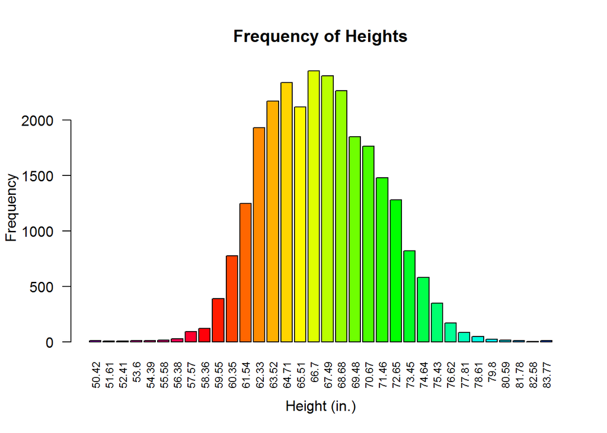

```r
height.frequency <- aggregate(list(length= yrbssn_df$height), list(height = yrbssn_df$height), FUN = length)
barplot(height = height.frequency$length, names.arg = round(height.frequency$height, digits = 2), main = 'Frequency of Heights',xlab = 'Height (in.)',ylab = 'Frequency', col = rainbow(n= length(height.frequency$height),start = .8,end = .6),las = 2, cex.names = .75)
```

#### weight (pounds)

[figure not shown]

```r
weight.frequency <- aggregate(list(length = yrbssn_df$weight), list(weight = yrbssn_df$weight), FUN = length)

hist(yrbssn_df$weight, xlab = 'Weight (lbs)',breaks = 25, col = cm.colors(25),labels = TRUE,main = 'Frequency of Weights (25 Bins)')
axis(side = 1,at = seq(50,400,10),labels = FALSE)
```

### Problem 3D

Produce tables (kable()) of the following:

#### mean weight by year (mean weight (x) by years 2011, 2013 (y))

```r
mean.weight.by.year <- aggregate(list(weight = yrbssn_df$weight), list(year = yrbssn_df$year),FUN = mean, na.rm = TRUE)
kable(mean.weight.by.year,align = 'c',caption = 'Mean Weight by Year')
```

Mean Weight by Year

| year | weight |
| --- | --- |
| 2011 | 148.4435 |
| 2013 | 149.3943 |

#### standard deviation weight by year (SD weight (x) by years 2011, 2013 (y))

```r
sd.weight.by.year <- aggregate(list(weight = yrbssn_df$weight),list(year = yrbssn_df$year), FUN = sd, na.rm = TRUE)
kable(sd.weight.by.year,align = 'c',caption = 'Standard Deviation from the Mean Weight by Year')
```

Standard Deviation from the Mean Weight by Year

| year | weight |
| --- | --- |
| 2011 | 37.69330 |
| 2013 | 37.17607 |

#### mean height by gender

```r
mean.height.by.gender <- aggregate(list(height = yrbssn_df$height), list(gender = yrbssn_df$gender), FUN = mean, na.rm = TRUE)
kable(mean.height.by.gender, align = 'c', caption = 'Mean Height by Gender')
```

Mean Height by Gender

| gender | height |
| --- | --- |
| female | 64.44435 |
| male | 69.72977 |

### Problem 3E

Boxplots of height for each grade

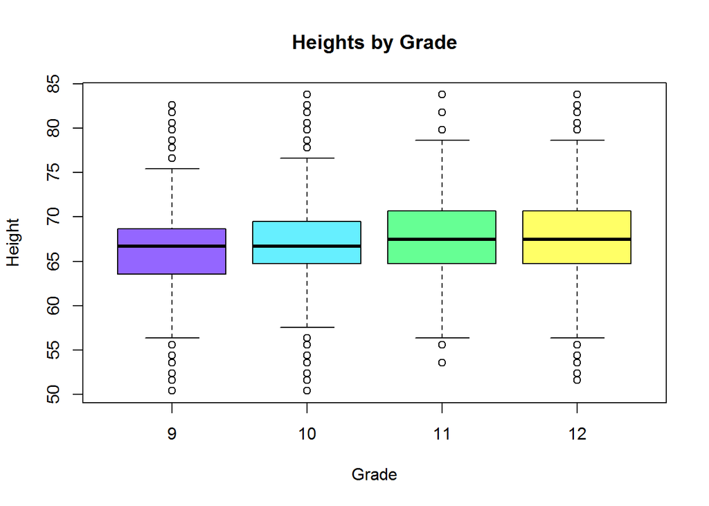

```r
boxplot(formula(yrbssn_df$height~yrbssn_df$grade), col = topo.colors(4, .6),xlab = 'Grade', ylab = 'Height', main = 'Heights by Grade')
```